# student

## Final Project Submission

Please fill out:

Business Understanding:

The real estate agency aims to provide advice to homeowners on how home renovations can increase the estimated value of their homes and by what amount. The agency wants to identify the factors that contribute most significantly to the increase in house prices after renovations. By understanding these factors, they can guide homeowners in making informed decisions about renovations that will yield a higher return on investment.

Data Understanding:

The dataset used for this analysis is the King County House Sales dataset. It contains information about various features of houses.

The available columns in the dataset are as follows:

• id: A property identification number

• date: Date of transaction

• price: Price of the house

• bedrooms: Number of bedrooms

• bathrooms: Number of bathrooms

• sqft_living: Square footage of the living space

• sqft_lot: Square footage of the lot

• floors: Total floors in the house

• waterfront: Whether the house is on a waterfront (1: yes, 0: no)

• view: Special view

• condition: Condition of the house

• grade: Grading level around the house

• sqft_above: Square footage of the house apart from the basement

• sqft_basement: Square footage of the basement area

• yr_built: Year when the house was built

• yr_renovated: Year when the house was renovated

• zipcode: Zip code of the house

• lat: Latitude coordinate of the house

• long: Longitude coordinate of the house

The goal of the analysis is to build a multiple linear regression model that can predict the impact of home renovations on the estimated value of houses. By identifying the significant predictors, the real estate agency can provide homeowners with actionable recommendations on which renovations are most likely to yield a higher return on investment.

```python
import pandas as pd
import numpy as np
from numbers import Number
import warnings
import sqlite3
import matplotlib.pyplot as plt
import seaborn as sns
from sklearn.model_selection import train_test_split
from sklearn import linear_model
from sklearn.neighbors import KNeighborsRegressor
from sklearn.preprocessing import PolynomialFeatures
from sklearn import metrics
from mpl_toolkits.mplot3d import Axes3D
from sklearn.preprocessing import LabelEncoder
from sklearn.metrics import mean_squared_error, r2_score
from sklearn.linear_model import LinearRegression
from sklearn.preprocessing import StandardScaler
from sklearn.model_selection import cross_val_score
from sklearn.model_selection import KFold
from sklearn.model_selection import GridSearchCV
from sklearn import linear_model
from sklearn.model_selection import train_test_split
from sklearn import metrics
import numpy as np

%matplotlib inline

warnings.filterwarnings('ignore')
```

loading the dataset , data showing and understanding

```python
df = pd.read_csv('kc_house_data.csv')
df
```

|  | id | date | price | bedrooms | bathrooms | sqft_living | sqft_lot | floors | waterfront | view | ... | grade | sqft_above | sqft_basement | yr_built | yr_renovated | zipcode | lat | long | sqft_living15 | sqft_lot15 |
| --- | --- | --- | --- | --- | --- | --- | --- | --- | --- | --- | --- | --- | --- | --- | --- | --- | --- | --- | --- | --- | --- |
| 0 | 7129300520 | 10/13/2014 | 221900.0 | 3 | 1.00 | 1180 | 5650 | 1.0 | NaN | NONE | ... | 7 Average | 1180 | 0.0 | 1955 | 0.0 | 98178 | 47.5112 | -122.257 | 1340 | 5650 |
| 1 | 6414100192 | 12/9/2014 | 538000.0 | 3 | 2.25 | 2570 | 7242 | 2.0 | NO | NONE | ... | 7 Average | 2170 | 400.0 | 1951 | 1991.0 | 98125 | 47.7210 | -122.319 | 1690 | 7639 |
| 2 | 5631500400 | 2/25/2015 | 180000.0 | 2 | 1.00 | 770 | 10000 | 1.0 | NO | NONE | ... | 6 Low Average | 770 | 0.0 | 1933 | NaN | 98028 | 47.7379 | -122.233 | 2720 | 8062 |
| 3 | 2487200875 | 12/9/2014 | 604000.0 | 4 | 3.00 | 1960 | 5000 | 1.0 | NO | NONE | ... | 7 Average | 1050 | 910.0 | 1965 | 0.0 | 98136 | 47.5208 | -122.393 | 1360 | 5000 |
| 4 | 1954400510 | 2/18/2015 | 510000.0 | 3 | 2.00 | 1680 | 8080 | 1.0 | NO | NONE | ... | 8 Good | 1680 | 0.0 | 1987 | 0.0 | 98074 | 47.6168 | -122.045 | 1800 | 7503 |
| ... | ... | ... | ... | ... | ... | ... | ... | ... | ... | ... | ... | ... | ... | ... | ... | ... | ... | ... | ... | ... | ... |
| 21592 | 263000018 | 5/21/2014 | 360000.0 | 3 | 2.50 | 1530 | 1131 | 3.0 | NO | NONE | ... | 8 Good | 1530 | 0.0 | 2009 | 0.0 | 98103 | 47.6993 | -122.346 | 1530 | 1509 |
| 21593 | 6600060120 | 2/23/2015 | 400000.0 | 4 | 2.50 | 2310 | 5813 | 2.0 | NO | NONE | ... | 8 Good | 2310 | 0.0 | 2014 | 0.0 | 98146 | 47.5107 | -122.362 | 1830 | 7200 |
| 21594 | 1523300141 | 6/23/2014 | 402101.0 | 2 | 0.75 | 1020 | 1350 | 2.0 | NO | NONE | ... | 7 Average | 1020 | 0.0 | 2009 | 0.0 | 98144 | 47.5944 | -122.299 | 1020 | 2007 |
| 21595 | 291310100 | 1/16/2015 | 400000.0 | 3 | 2.50 | 1600 | 2388 | 2.0 | NaN | NONE | ... | 8 Good | 1600 | 0.0 | 2004 | 0.0 | 98027 | 47.5345 | -122.069 | 1410 | 1287 |
| 21596 | 1523300157 | 10/15/2014 | 325000.0 | 2 | 0.75 | 1020 | 1076 | 2.0 | NO | NONE | ... | 7 Average | 1020 | 0.0 | 2008 | 0.0 | 98144 | 47.5941 | -122.299 | 1020 | 1357 |

21597 rows × 21 columns

```python
df.columns
```

```
Index(['id', 'date', 'price', 'bedrooms', 'bathrooms', 'sqft_living',
       'sqft_lot', 'floors', 'waterfront', 'view', 'condition', 'grade',
       'sqft_above', 'sqft_basement', 'yr_built', 'yr_renovated', 'zipcode',
       'lat', 'long', 'sqft_living15', 'sqft_lot15'],
      dtype='object')
```

```python
df.info()
```

```
<class 'pandas.core.frame.DataFrame'>
RangeIndex: 21597 entries, 0 to 21596
Data columns (total 21 columns):
 #   Column         Non-Null Count  Dtype
---  ------         --------------  -----
 0   id             21597 non-null  int64
 1   date           21597 non-null  object
 2   price          21597 non-null  float64
 3   bedrooms       21597 non-null  int64
 4   bathrooms      21597 non-null  float64
 5   sqft_living    21597 non-null  int64
 6   sqft_lot       21597 non-null  int64
 7   floors         21597 non-null  float64
 8   waterfront     19221 non-null  object
 9   view           21534 non-null  object
 10  condition      21597 non-null  object
 11  grade          21597 non-null  object
 12  sqft_above     21597 non-null  int64
 13  sqft_basement  21597 non-null  object
 14  yr_built       21597 non-null  int64
 15  yr_renovated   17755 non-null  float64
 16  zipcode        21597 non-null  int64
 17  lat            21597 non-null  float64
 18  long           21597 non-null  float64
 19  sqft_living15  21597 non-null  int64
 20  sqft_lot15     21597 non-null  int64
dtypes: float64(6), int64(9), object(6)
memory usage: 3.5+ MB
```

```python
df.shape
```

```
(21597, 21)
```

```python
df.isnull().any()
```

```
id               False
date             False
price            False
bedrooms         False
bathrooms        False
sqft_living      False
sqft_lot         False
floors           False
waterfront        True
view              True
condition        False
grade            False
sqft_above       False
sqft_basement    False
yr_built         False
yr_renovated      True
zipcode          False
lat              False
long             False
sqft_living15    False
sqft_lot15       False
dtype: bool
```

```python
df.isnull().sum()
```

```
id                  0
date                0
price               0
bedrooms            0
bathrooms           0
sqft_living         0
sqft_lot            0
floors              0
waterfront       2376
view               63
condition           0
grade               0
sqft_above          0
sqft_basement       0
yr_built            0
yr_renovated     3842
zipcode             0
lat                 0
long                0
sqft_living15       0
sqft_lot15          0
dtype: int64
```

Checking for duplicates

```python
df.duplicated().sum()
```

```
0
```

DATA PREPARATION

viewing the columns with null data, cleaning and handling outliers,droping columns changing column,etc

DATA CLEANING

Waterfront

```python
# viewing the waterfront column to see if it has any null values

df['waterfront']
```

```
0        NaN
1         NO
2         NO
3         NO
4         NO
        ...
21592     NO
21593     NO
21594     NO
21595    NaN
21596     NO
Name: waterfront, Length: 21597, dtype: object
```

```python
df['waterfront'].value_counts()
```

```
NO     19075
YES      146
Name: waterfront, dtype: int64
```

```python
df['waterfront'].isnull().sum()
```

```
2376
```

```python
df['waterfront'].fillna('No', inplace=True)
```

```python
df['waterfront'].isnull().sum()
```

```
0
```

```python
# change = {'No':0, 'Yes':1}
# df['waterfront'] = df['waterfront'].replace({'No':0, 'Yes':1})
label_encoder = LabelEncoder()
df['waterfront'] = label_encoder.fit_transform(df['waterfront'])
df['waterfront'].value_counts()
```

```
0    19075
1     2376
2      146
Name: waterfront, dtype: int64
```

```python
df['waterfront']
```

```
0        1
1        0
2        0
3        0
4        0
        ..
21592    0
21593    0
21594    0
21595    1
21596    0
Name: waterfront, Length: 21597, dtype: int32
```

View:Replace the null values with None

```python
df['view'].head()
```

```
0    NONE
1    NONE
2    NONE
3    NONE
4    NONE
Name: view, dtype: object
```

```python
df['view'].value_counts()
```

```
NONE         19422
AVERAGE        957
GOOD           508
FAIR           330
EXCELLENT      317
Name: view, dtype: int64
```

```python
df['view'].isnull().sum()
```

```
63
```

```python
df['view'].fillna('None', inplace=True)
```

```python
label_encoder = LabelEncoder()
df['view'] = label_encoder.fit_transform(df['view'])
df['view'].value_counts()
```

```
4    19422
0      957
3      508
2      330
1      317
5       63
Name: view, dtype: int64
```

```python
df['view'].isnull().sum()
```

```
0
```

Viewing the grade column

```python
df['grade']
```

```
0            7 Average
1            7 Average
2        6 Low Average
3            7 Average
4               8 Good
             ...
21592           8 Good
21593           8 Good
21594        7 Average
21595           8 Good
21596        7 Average
Name: grade, Length: 21597, dtype: object
```

Converting the grade column to a categorical column

```python
df['grade'].value_counts()
```

```
7 Average        8974
8 Good           6065
9 Better         2615
6 Low Average    2038
10 Very Good     1134
11 Excellent      399
5 Fair            242
12 Luxury          89
4 Low              27
13 Mansion         13
3 Poor              1
Name: grade, dtype: int64
```

```python
new_grades = {'7 Average':7, '8 Good': 8, '9 Better': 9, '6 Low Average':6, '10 Very Good': 10, '11 Excellent' :11, '5 Fair':5, '12 Luxury' : 12, '4 Low':4, '13 Mansion':13, '3 Poor':3 }
df['grade'] = df['grade'].map(new_grades)
```

```python
df['grade']
```

```
0        7
1        7
2        6
3        7
4        8
        ..
21592    8
21593    8
21594    7
21595    8
21596    7
Name: grade, Length: 21597, dtype: int64
```

```python
df['grade'].value_counts()
```

```
7     8974
8     6065
9     2615
6     2038
10    1134
11     399
5      242
12      89
4       27
13      13
3        1
Name: grade, dtype: int64
```

Conditional column:

```python
df['condition'].value_counts()
```

```
Average      14020
Good          5677
Very Good     1701
Fair           170
Poor            29
Name: condition, dtype: int64
```

```python
label_encoder = LabelEncoder()
df['condition'] = label_encoder.fit_transform(df['condition'])
df['condition'].value_counts()
```

```
0    14020
2     5677
4     1701
1      170
3       29
Name: condition, dtype: int64
```

```python
df['condition']
```

```
0        0
1        0
2        0
3        4
4        0
        ..
21592    0
21593    0
21594    0
21595    0
21596    0
Name: condition, Length: 21597, dtype: int32
```

```python
df.head()
```

|  | id | date | price | bedrooms | bathrooms | sqft_living | sqft_lot | floors | waterfront | view | ... | grade | sqft_above | sqft_basement | yr_built | yr_renovated | zipcode | lat | long | sqft_living15 | sqft_lot15 |
| --- | --- | --- | --- | --- | --- | --- | --- | --- | --- | --- | --- | --- | --- | --- | --- | --- | --- | --- | --- | --- | --- |
| 0 | 7129300520 | 10/13/2014 | 221900.0 | 3 | 1.00 | 1180 | 5650 | 1.0 | 1 | 4 | ... | 7 | 1180 | 0.0 | 1955 | 0.0 | 98178 | 47.5112 | -122.257 | 1340 | 5650 |
| 1 | 6414100192 | 12/9/2014 | 538000.0 | 3 | 2.25 | 2570 | 7242 | 2.0 | 0 | 4 | ... | 7 | 2170 | 400.0 | 1951 | 1991.0 | 98125 | 47.7210 | -122.319 | 1690 | 7639 |
| 2 | 5631500400 | 2/25/2015 | 180000.0 | 2 | 1.00 | 770 | 10000 | 1.0 | 0 | 4 | ... | 6 | 770 | 0.0 | 1933 | NaN | 98028 | 47.7379 | -122.233 | 2720 | 8062 |
| 3 | 2487200875 | 12/9/2014 | 604000.0 | 4 | 3.00 | 1960 | 5000 | 1.0 | 0 | 4 | ... | 7 | 1050 | 910.0 | 1965 | 0.0 | 98136 | 47.5208 | -122.393 | 1360 | 5000 |
| 4 | 1954400510 | 2/18/2015 | 510000.0 | 3 | 2.00 | 1680 | 8080 | 1.0 | 0 | 4 | ... | 8 | 1680 | 0.0 | 1987 | 0.0 | 98074 | 47.6168 | -122.045 | 1800 | 7503 |

5 rows × 21 columns

Drop columns:

Some columns wont contribute much to our models.

```python
dropping_columns = ["id","date",'yr_renovated','waterfront','sqft_basement','lat','long','zipcode','sqft_living15','sqft_lot15','sqft_above']
df.drop(dropping_columns, inplace=True, axis = 1)
```

```python
df.columns
```

```
Index(['price', 'bedrooms', 'bathrooms', 'sqft_living', 'sqft_lot', 'floors',
       'view', 'condition', 'grade', 'yr_built'],
      dtype='object')
```

```python
df.describe()
```

|  | price | bedrooms | bathrooms | sqft_living | sqft_lot | floors | view | condition | grade | yr_built |
| --- | --- | --- | --- | --- | --- | --- | --- | --- | --- | --- |
| count | 2.159700e+04 | 21597.000000 | 21597.000000 | 21597.000000 | 2.159700e+04 | 21597.000000 | 21597.000000 | 21597.000000 | 21597.000000 | 21597.000000 |
| mean | 5.402966e+05 | 3.373200 | 2.115826 | 2080.321850 | 1.509941e+04 | 1.494096 | 3.727555 | 0.852665 | 7.657915 | 1970.999676 |
| std | 3.673681e+05 | 0.926299 | 0.768984 | 918.106125 | 4.141264e+04 | 0.539683 | 0.924370 | 1.266732 | 1.173200 | 29.375234 |
| min | 7.800000e+04 | 1.000000 | 0.500000 | 370.000000 | 5.200000e+02 | 1.000000 | 0.000000 | 0.000000 | 3.000000 | 1900.000000 |
| 25% | 3.220000e+05 | 3.000000 | 1.750000 | 1430.000000 | 5.040000e+03 | 1.000000 | 4.000000 | 0.000000 | 7.000000 | 1951.000000 |
| 50% | 4.500000e+05 | 3.000000 | 2.250000 | 1910.000000 | 7.618000e+03 | 1.500000 | 4.000000 | 0.000000 | 7.000000 | 1975.000000 |
| 75% | 6.450000e+05 | 4.000000 | 2.500000 | 2550.000000 | 1.068500e+04 | 2.000000 | 4.000000 | 2.000000 | 8.000000 | 1997.000000 |
| max | 7.700000e+06 | 33.000000 | 8.000000 | 13540.000000 | 1.651359e+06 | 3.500000 | 5.000000 | 4.000000 | 13.000000 | 2015.000000 |

Data Visualization

To check missing values

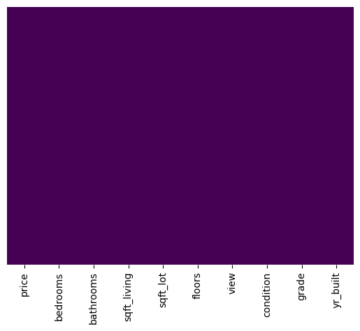

```python
sns.heatmap(df.isnull(),cbar=False,yticklabels=False,cmap='viridis')
```

According to the above figure the dataset now has no missing values this is because the figure has only one shade.

To check the correlation between the variables

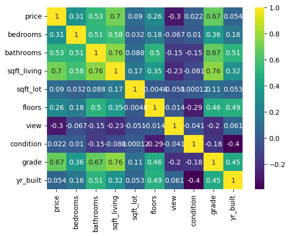

```python
plt.Figure(figsize=(10,10))
sns.heatmap(df.corr(),annot=True,cmap='viridis')
```

Here we can infer that "floors" and has weak negative correlation with "sqft_lot"

whereas "sqft_living it has strong positive correlation with "bathrooms".

Checking for Outliers

```python
# Selecting only the numerical columns
numerical_columns = ['price', 'bedrooms', 'bathrooms', 'sqft_living', 'sqft_lot', 'floors', 'yr_built']
numerical_df = df[numerical_columns]

# Calculating z-scores for all numerical columns
z_scores = (numerical_df - numerical_df.mean()) / numerical_df.std()

# Setting a threshold for outlier detection
threshold = 3

# Checking for outliers by identifying values with z-score greater than the threshold
outliers = df[(z_scores > threshold).any(axis=1)]


print(outliers)
```

```
           price  bedrooms  bathrooms  sqft_living  sqft_lot  floors  view  \
5      1230000.0         4       4.50         5420    101930     1.0     4
21     2000000.0         3       2.75         3050     44867     1.0     1
145     921500.0         4       2.50         3670    315374     2.0     4
153    2250000.0         4       3.25         5180     19850     2.0     3
199     385000.0         3       1.75         1350    155073     1.0     4
...          ...       ...        ...          ...       ...     ...   ...
21532  1060000.0         2       1.50         2370    184231     2.0     4
21535  1380000.0         5       4.50         4350     13405     2.0     4
21552  1700000.0         4       3.50         3830      8963     2.0     4
21560  3570000.0         5       4.50         4850     10584     2.0     1
21574  1220000.0         4       3.50         4910      9444     1.5     4

       condition  grade  yr_built
5              0     11      2001
21             0      9      1968
145            2      9      1994
153            0     12      2006
199            2      7      1969
...          ...    ...       ...
21532          0     11      2005
21535          0     11      2014
21552          0     10      2014
21560          0     10      2007
21574          0     11      2007

[963 rows x 10 columns]
```

Visualize the outliers

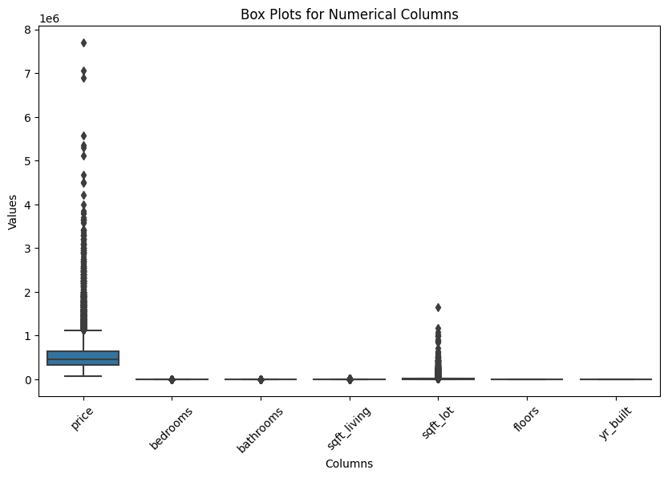

```python
numerical_columns = ['price', 'bedrooms', 'bathrooms', 'sqft_living', 'sqft_lot', 'floors', 'yr_built']
numerical_df = df[numerical_columns]

plt.figure(figsize=(10,6))
sns.boxplot(data=numerical_df)
plt.xticks(rotation=45)
plt.title("Box Plots for Numerical Columns")
plt.xlabel("Columns")
plt.ylabel("Values")
plt.show()
```

To check for skewness :

Skewness measures the asymmetry of the distribution.

close to 0 : indicates a symmetric distribution...ie bathrooms

positively skewed frequency curve: there are more observations below the mean....ie. sqft_lot

negative skewed frequency curve: there are more observations above the mean.....ie yr_built

```python
skewness = df.skew(axis=0, skipna=True, numeric_only=True,)
skewness
```

```
price           4.023365
bedrooms        2.023641
bathrooms       0.519709
sqft_living     1.473215
sqft_lot       13.072604
floors          0.614497
view           -3.363849
condition       1.212104
grade           0.788237
yr_built       -0.469450
dtype: float64
```

Plotting the skewness of the columns in the dataset

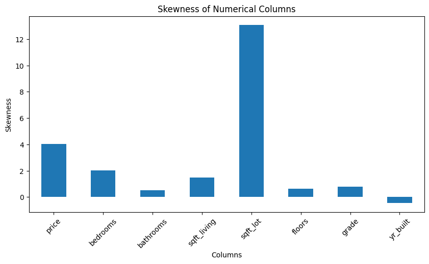

```python
numerical_columns = df.select_dtypes(include=['float64', 'int64'])

# Calculate skewness for each numerical column
skewness = numerical_columns.skew()

# Plotting the skewness
plt.figure(figsize=(10,5))
skewness.plot(kind='bar')
plt.title('Skewness of Numerical Columns')
plt.xlabel('Columns')
plt.ylabel('Skewness')
plt.xticks(rotation=45)
plt.show()
```

LINEAR REGRESSION

1). PRICE VS GRADE

There is a close relationship between the price of a house and the grade where the fact on whether a house is a graded as a mansion,luxury,excellent, better it will affect the price of the house.

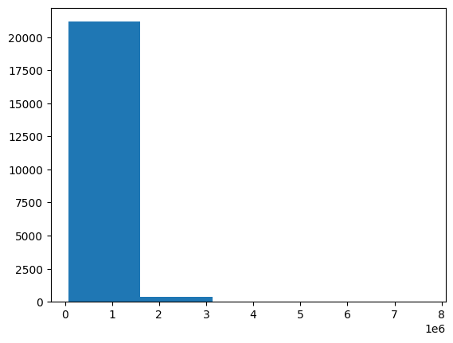

```python
# visualizing of the price column
plt.hist('price',data=df,bins=5)
plt.show()
```

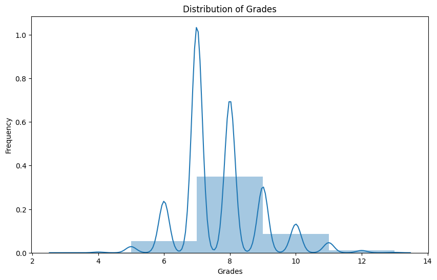

```python
# visualizing the distribution of the grade column
fig = plt.figure(figsize=(10,6))
sns.distplot(df['grade'], bins=5)
plt.title('Distribution of Grades')
plt.xlabel('Grades')
plt.ylabel('Frequency')
plt.show()
```

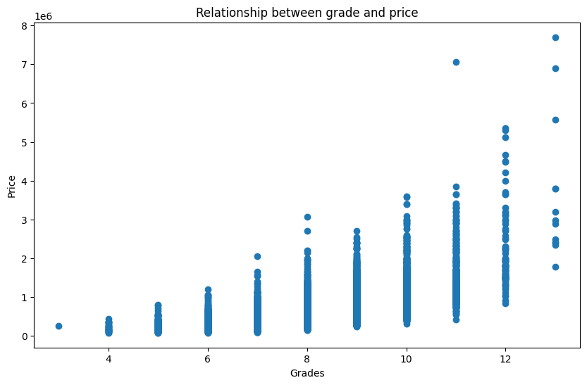

```
The coefficient for our model is  [211516.22123553]
The intercept for our model is  -1078219.9856528589
The model performance for training set
--------------------------------------
RMSE is 271483.82054584136
R2 score is 0.43399193438808736
Mse is 73703464818.1666


The model performance for testing set
--------------------------------------
RMSE is 271483.82054584136
R2 score is 0.43399193438808736
Mse is 73703464818.1666
```

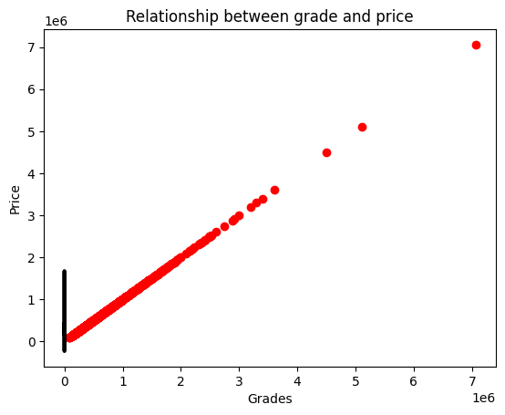

```python
#visualize the relationship between the price and the grade
# Plotting the regression line
fig = plt.figure(figsize=(10,6))
plt.scatter(df['grade'], df['price'])
plt.xlabel('Grades')
plt.ylabel('Price')
plt.title('Relationship between grade and price')
plt.show()

# split the data into training and testing sets
X = df[['grade']]
y= df['price']
X_train, X_test, y_train, y_test = train_test_split(X, y, test_size=0.2, random_state=42)

#create an fit the linear regression model
model = linear_model.LinearRegression()
model.fit(X_train, y_train)

#retrieve the intercept and the coefficient from the model
coefficients = model.coef_
intercept = model.intercept_
print("The coefficient for our model is ", coefficients)
print ("The intercept for our model is ", intercept)

#predict the prices
y_pred = model.predict(X_test)

#evaluate the model
plt.scatter(y_test, y_test, color='red')
plt.plot(X_test, y_pred, color='Black', linewidth=3)
plt.xlabel('Grades')
plt.ylabel('Price')
plt.title('Relationship between grade and price')


#Calculating the models metrics
print("The model performance for training set")
print("--------------------------------------")
print('RMSE is {}'.format(np.sqrt(metrics.mean_squared_error(y_test, y_pred))))
print('R2 score is {}'.format(metrics.r2_score(y_test, y_pred)))
print('Mse is {}'.format(metrics.mean_squared_error(y_test, y_pred)))
print("\n")
print("The model performance for testing set")
print("--------------------------------------")
print('RMSE is {}'.format(np.sqrt(metrics.mean_squared_error(y_test, y_pred))))
print('R2 score is {}'.format(metrics.r2_score(y_test, y_pred)))
print('Mse is {}'.format(metrics.mean_squared_error(y_test, y_pred)))
print("\n")
```

• RMSE (Root Mean Squared Error): The RMSE value is 271,483.82054584136. It represents the average difference between the predicted and actual price values. Lower RMSE values indicate better predictive performance. In this case, the RMSE suggests that, on average, the model's predictions deviate from the actual prices by approximately $271,484.

• R2 score: The R2 score is 0.43399193438808736. This metric measures the proportion of variance in the target variable (price) explained by the predictor variable (grade). An R2 score closer to 1 indicates a better fit, where higher values signify that more of the variation in the price can be attributed to the grade. In this case, the R2 score suggests that approximately 43.4% of the price variation can be explained by the grade variable.

• MSE (Mean Squared Error): The MSE value is 73,703,464,818.1666. Similar to RMSE, MSE represents the average squared difference between predicted and actual price values. Higher MSE values indicate larger prediction errors. In this case, the MSE is quite large, reflecting significant variability between predicted and actual prices.

Interpretation: Based on these results, the linear regression model doesn't appear to be a strong fit for the data. The relatively high RMSE and MSE values indicate that there is substantial prediction error, with the model's predictions deviating from the actual prices by a considerable amount. Additionally, the R2 score of 0.433 suggests that only around 43.4% of the price variability can be explained by the grade variable alone. Therefore, it may be necessary to explore additional variables or consider more complex modeling techniques to improve the model's performance and achieve a better fit to the data.

2): LINEAR REGRESSION MODEL OF PRICE AND SQFT_LIVING

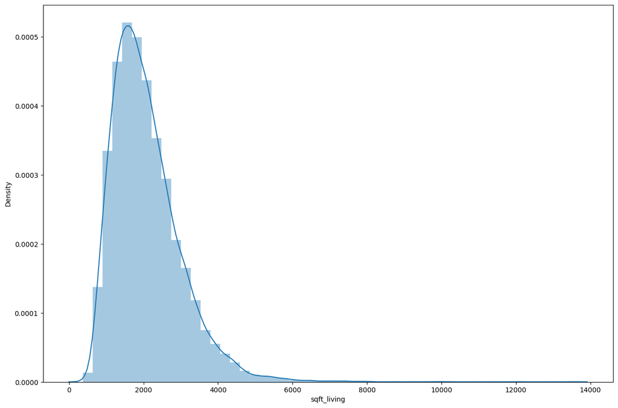

```python
# viewing the sqft_living column
# plt.hist('sqft_living',data=df,bins=5)
# plt.show()
fig,axes=plt.subplots(nrows=1,ncols=1,figsize=(15,10))
sns.distplot(df['sqft_living'],hist=True,kde=True,rug=False,label='sqft_living',norm_hist=True)
```

```python
# Splitting the data into training and testing sets
X_train, X_test, y_train, y_test = train_test_split(df[['sqft_living']], df['price'], test_size=0.2, random_state=42)

# Creating and fitting the linear regression model object using the training data
reg = linear_model.LinearRegression()
reg.fit(X_train, y_train)

# Making predictions on the testing data
pred = reg.predict(X_test)

# Printing the results
print('Linear Model')
mse = metrics.mean_squared_error(y_test, pred)
print('Mean Squared Error:', round(mse, 2))
rmse = np.sqrt(mse)
r2_train = reg.score(X_train, y_train)
print('R-squared (Training):', round(r2_train, 3))
r2_test = reg.score(X_test, y_test)
print('R-squared (Testing):', round(r2_test, 3))

print('Root Mean Squared Error (RMSE):', round(rmse, 2))
print('R-squared (Training):', round(r2_train, 3))
print('R-squared (Testing):', round(r2_test, 3))
print('Intercept:', reg.intercept_)
print('Coefficient:', reg.coef_)
```

```
Linear Model
Mean Squared Error: 65977373783.62
R-squared (Training): 0.492
R-squared (Testing): 0.493
Root Mean Squared Error (RMSE): 256860.61
R-squared (Training): 0.492
R-squared (Testing): 0.493
Intercept: -46447.34551807004
Coefficient: [282.20150555]
```

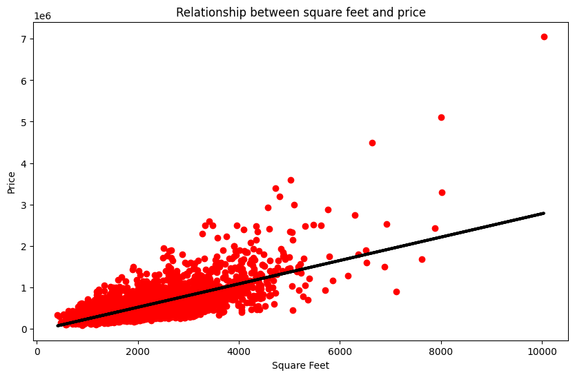

```python
# Plotting the regression line
plt.figure(figsize=(10,6))
plt.scatter(X_test, y_test, color='red')
plt.plot(X_test, pred, color='black', linewidth=3)
plt.xlabel('Square Feet')
plt.ylabel('Price')
plt.title('Relationship between square feet and price')
plt.show()
```

Based on the metrics provided:

1. Mean Squared Error (MSE): The MSE value is 65,977,373,783.62. Since the MSE represents the average squared difference between the predicted and actual values, a lower value is desirable. In this case, the high MSE suggests that the model's predictions have a large average deviation from the actual values, indicating poorer model fit.
2. R-squared: The R-squared values for both the training and testing sets are 0.492 and 0.493, respectively. R-squared measures the proportion of variance in the target variable that can be explained by the model. A higher R-squared indicates a better fit. In this case, the R-squared values are relatively low, suggesting that only about 49.2% - 49.3% of the variance in the target variable is explained by the linear model.
3. Root Mean Squared Error (RMSE): The RMSE value is 256,860.61. Similar to the MSE, a lower RMSE is preferred as it represents a smaller average prediction error. However, the given value of RMSE is quite high, indicating significant deviations between the predicted and actual values.
4. Intercept and Coefficient: The intercept is -46447.35, and the coefficient is 282.20150555. These represent the y-intercept and slope, respectively, of the linear equation. They indicate the baseline value and the effect of the independent variable on the dependent variable. Considering all these metrics, the model does not appear to be a good fit for the data. The high MSE and RMSE suggest substantial prediction errors, while the relatively low R-squared values indicate that the model explains only a small portion of the variance in the target variable. Therefore, further model improvement or exploration may be necessary to achieve a better fit.

MULTIPLE LINEAR REGRESSION MODEL

```python
X = df[['bathrooms', 'bedrooms', 'sqft_lot', 'sqft_living','floors', ]]
y= df['price']
X_train, X_test, y_train, y_test = train_test_split(X, y, test_size=0.2, random_state=42)

reg=linear_model.LinearRegression()
reg.fit(X_train,y_train)
pred=reg.predict(X_test)

print('Multiple Linear Regression')
mean_squared_error=metrics.mean_squared_error(y_test,pred)

print('mean squared error(MSE)', round(np.sqrt(mean_squared_error),2))
print('R squared training',round(reg.score(X_train,y_train),3))
print('R squared training', round(reg.score(X_test,y_test),3))
print('Intercept: ', reg.intercept_)
print('Coefficient:', reg.coef_)
print("\n")
```

```
Multiple Linear Regression
mean squared error(MSE) 255315.14
R squared training 0.511
R squared training 0.499
Intercept:  89732.72526580625
Coefficient: [ 8.60216010e+03 -6.61937453e+04 -4.58141974e-01  3.19248248e+02
 -8.64614668e+02]
```

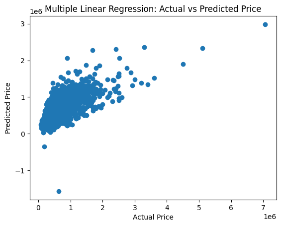

```python
plt.scatter(y_test, pred)
plt.xlabel('Actual Price')
plt.ylabel('Predicted Price')
plt.title('Multiple Linear Regression: Actual vs Predicted Price')
plt.show()
```

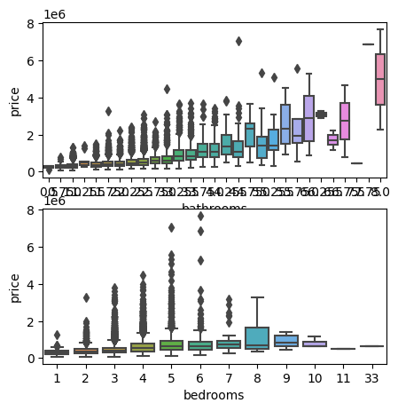

[figure not shown]

[figure not shown]

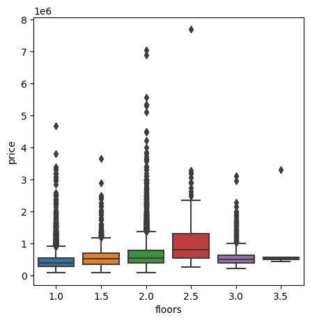

```python
fig,ax=plt.subplots(2,1,figsize=(5,5))
sns.boxplot(x=df['bathrooms'],y=df['price'],ax=ax[0])
sns.boxplot(x=df['bedrooms'],y=df['price'],ax=ax[1])
_ , axes = plt.subplots(1, 1, figsize=(5,5))
sns.boxplot(x=df['sqft_living'],y=df['price'])
_ , axes = plt.subplots(1, 1, figsize=(5,5))
sns.boxplot(x=df['sqft_lot'],y=df['price'])
_ , axes = plt.subplots(1, 1, figsize=(5,5))
sns.boxplot(x=df['floors'],y=df['price'])
```

```python
x = df[['bathrooms', 'bedrooms', 'sqft_lot', 'sqft_living','floors', 'bedrooms', 'grade', 'yr_built']]
y = df['price']
x_train, x_test, y_train, y_test = train_test_split(x, y, test_size=0.2, random_state=42)

model = linear_model.LinearRegression()
model.fit(x_train, y_train)
pred = model.predict(x_test)
print('Multiple Linear Regression 2')
mean_squared_error=metrics.mean_squared_error(y_test,pred)
print('mean squared error(MSE)', round(np.sqrt(mean_squared_error),2))
print('R squared training',round(model.score(x_train,y_train),3))
print('R squared training', round(model.score(x_test,y_test),3))
print('Intercept: ', model.intercept_)
print('Coefficient:', model.coef_)
```

```
Multiple Linear Regression 2
mean squared error(MSE) 229016.19
R squared training 0.621
R squared training 0.597
Intercept:  7478566.369777217
Coefficient: [ 5.75708783e+04 -2.62628339e+04 -2.99281298e-01  1.88941352e+02
  1.85176618e+04 -2.62628339e+04  1.32271986e+05 -4.21685708e+03]
```

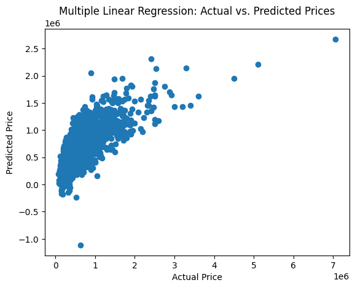

```python
plt.scatter(y_test, pred)
plt.xlabel('Actual Price')
plt.ylabel('Predicted Price')
plt.title('Multiple Linear Regression: Actual vs. Predicted Prices')
plt.show()
```